*JSC270, Winter 2020 - Prof. Chevalier*

# Yelp Data Analysis

### Author: Zhenyu Wang

### Time: Febuary, 2020

## Contents

### Introduction

1. Permissions
2. An Overview of the data

### Characteristics of All Businesses

1. Location: Where do the businesses that the dataset emcompass locate at?
2. Category: The most frequent business categories.
3. Convenience: What types of establishments tend to have higher bike parking.
4. Popularity: What is the relationship between the number of reviews and the rating?

### Characteristics of Businesses in GTA

1. Category: The most frequent business categories in GTA, how does it compare with all businesses?
2. Popularity: The top franchises in the city
3. Popularity: Relationship between business locationes and reviews
4. Example: Characteristics of Tim Hortons and Starbucks in GTA

### View the Businesses at User's Perspective

1. A small group of users that is responsible for most reviews
2. Similarity of language in users' reviews of GTA's Tim Horton's and Starbucks
3. Automatic Dectection of paid reviewers

### Conclusion

1. Conclusion
2. Limitation
3. Future Steps

## Introduction

Imagine that you travel to a city that you have never been to. You do not have friends here, but you want to know where is the best restaurant in the city. If this scenario happened in 10 years ago, you might want to ask a passingby for advice or just randomly picked a restaurant that looked good. But now, you have **Yelp**, which publishes crowd-sourced reviews about local businesses and provide comprehensive information about every aspect of local businesses. Using **Yelp**, you have access to **148 million** reviews provided by different users around the world.

These reviews not only benefit users, but also form a huge and valuable dataset. There are two unique characteristics about this dataset,

1. This dataset contains almost everything about local businesses.
2. The dataset contains reviews provided by real users.

Based on two characteristics, we want to implement further investigation using this dataset. They are listed as following,

1. Characteristics of all Businesses in the dataset, Including their popularity, location, etc.
2. Characteristics of Businesses in the dataset in a particular region, compare it with the whole data set. Since we are in Toronto, so we will do investigation on the GTA.
3. Characteristics of reviews in the dataset, and make connection with users and reviews.

The purpose of the investigation is to benefit the businesses, and provide **Yelp** more suggestions to improve their review. This report will not go beyond these two purposes.

### Permissions

We will use the data provided by **Yelp Inc.**, it is our obligation to understand the laws and regulations of the dataset. I will explain them using the **YELP DATASET TERMS OF USE** in terms of what we can do and we can't do.

1. What we **Can** do

**Acadamic Purpose**. The purpose of using this dataset should be fully under an acadamic purpose. For example, you may use the data to develop a research about local businesses for an assignment in the school. For other purposes of using the dataset, we have to ask **Yelp Inc.** for extra authority.

**Publish** We are allowed to publicize our study (with fully acadamic purposes), but we are not allowed to make any other statements.

1. What we **Can't** do

**Commerical Purpose** The data set should not be used for any commerical purposes. For instance, we cannot use the dataset to benefit our own local business by updating or creating our own business listing information, or create our own business information. Also, we cannot sell, sublience this datasets to others.

**Share the data with the third party** We can not the data to a company that is competitive in nature with Yelp, this may results in conflict of interests. For example, sharing the reuslt of the study with Google Review.

**Violation of Laws** Any usage of this dataset that violates the law and regulation should not be permitted. This includes the privacy disclosure and business secrets.

**Disparage Yelp Products** We cannot use this dataset for any purposes that may disparage Yelp products. Also, we may not use this dataset to make readers think the Yelp company itself is the author of reviews or other information in the data sets.

### An Overview of the data

I will go through important attributes of datasets one by one and then describe the relationship between attributes in datasets. We have 6 datasets in total. They are a subset of Yelp

1. The **tip** dataset contains six attributes. User id records the id of user who gives the tip. Business id is the id of business this tip corresponds to. Text records the text of the tip, and date recorded when the tip is recorded. Compliment Count record how many times the tip is complimented.
2. The **photo** dataset contains four attributes. They are **photo_id**, its stores the unique of a photo, **caption**, which is the caption of a figure. It also contains business id, which is the business that this picture corresponds to. Tha last is the **label** of the photo.
3. The **checkin** dataset contains two attributes. One is **business-id**, the other is **date**, which records the time of checkin.

These datasets are not so essential for the purpose of research, but it is always good to take a look at them.

**Some important common attributes and connections between dataframes** **Business ID** attribute is the key of business in the dataset, it is a common attribute in different datasets we can merge **Review**, **tip**, **checkin**, **photo** dataframes with **Business** based on this attribute to gain more information about businesses in these datasets. **User ID** attribute of user in the dataset, it is a common attribute in different dataset. We can merge **Review**, **tip**, with **User** dataframes to know about users in the dataframe. Business and User are two most important parts of the datasets.

## Characteristics of All Businesses

### Location

#### Where do the businesses that the dataset emcompass locate at?

We know this dataset is a subset of all businesses stored in Yelp. Since the dataset is not all the information, it may not cover all the businesses around the world. So, we first need to know more about the data, including **Where do the businesses that the dataset emcompass locate at?** I think only discussing about city is not enough to know about their locations. This questions can be divided into 2 subquestions.

1. Where do these businesses locate at? In which countries, states and cities?
2. Which cities contain most businesses in the data set?

The procedure I will use is as the following:

1. Find the allocations of businesses in the dataset using the world map.
2. Discuss locations of businesses in terms of their countries.
3. Discuss locations of businesses in terms of their states and cities.

Firstly, The most intuitive way for us to view the allocation is through map. Using longititude and latitude provided in the dataset, we can plot locations of businesses in the dataset. In the world map below, I plot all the businesses in the dataset in red dots.

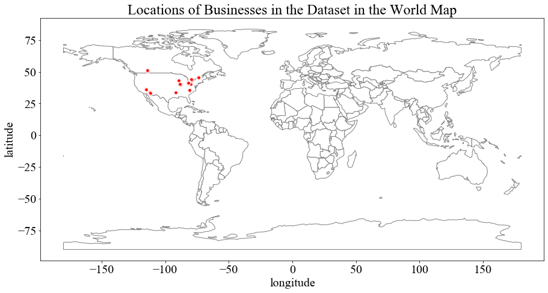

We see all cities that contain business in the dataset are located in North America, in particular, the **United States** and **Canada**. From the world map, we can also see these cities are not widely spread in two contries, instead, they are concentrated in some parts. The next step is to find how many businesses are there in each country. The data set does not tell the country directly, but we can use the post code to determine country (Postcode in US has exactly five characters). I will use piechart to visualize them.

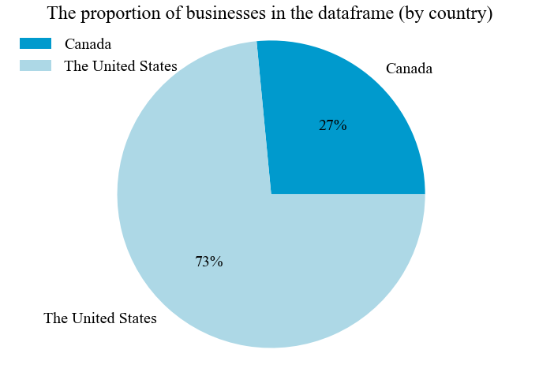

From the piechart, we see about 3 quarters of businesses are located in the United States, rest of them are in Canada. The next step is to figure out which states in these two countries contain those cities with businesses. Let's print out the list of the states first. Surprisingly, we find some states that do not have 2-letter-abbreviation. Obviously, they are not name of states in the US or Canada. Let's take a look of what is behind these states.

```
3-letter-abbreviation states:
BAS
XGM
XWY
CON
DUR
XGL
DOW
```

By looking at them carefully, we see there must be mistakes when recording these businesses. Since the states and cities indicate that they are European cities, but their latitudes and longitudes show that they are actually in US and Canada. Since the total length of our dataset is more than 190000, and wrong data only contain 11 businesses, so, dropping them will not affect the result too much, I will drop them for now.

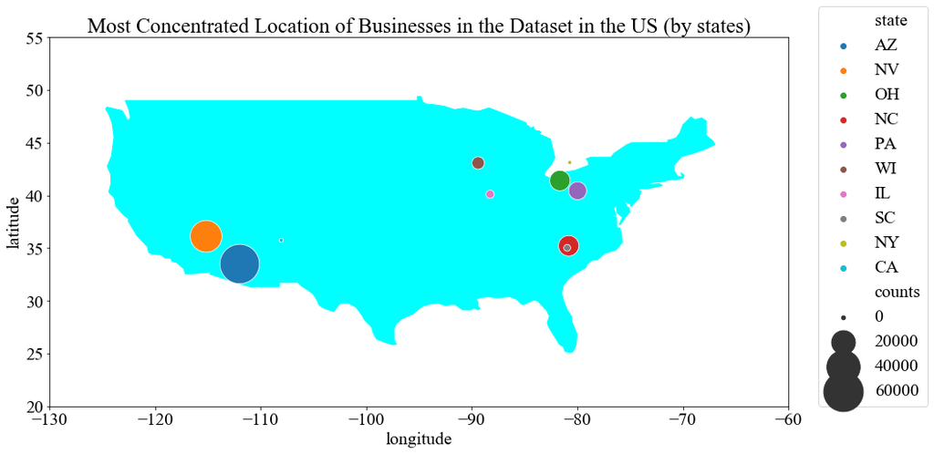

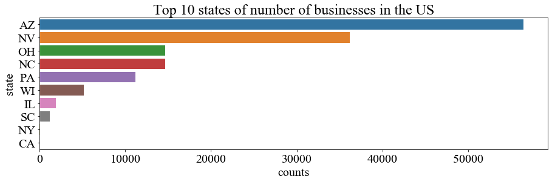

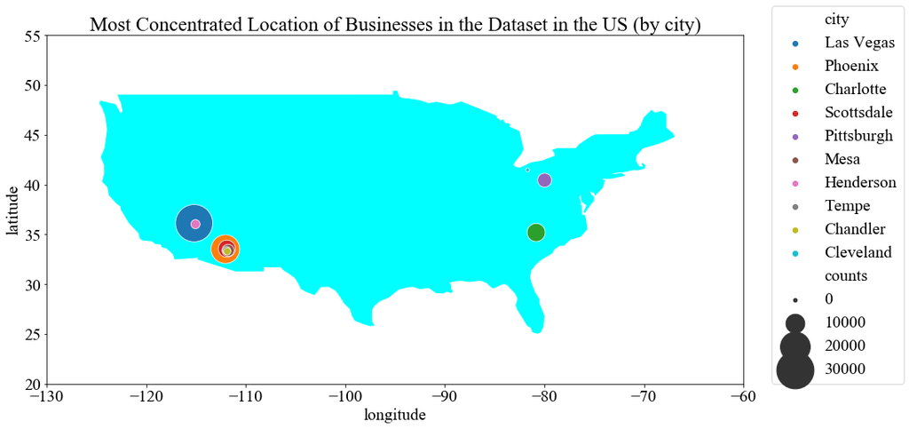

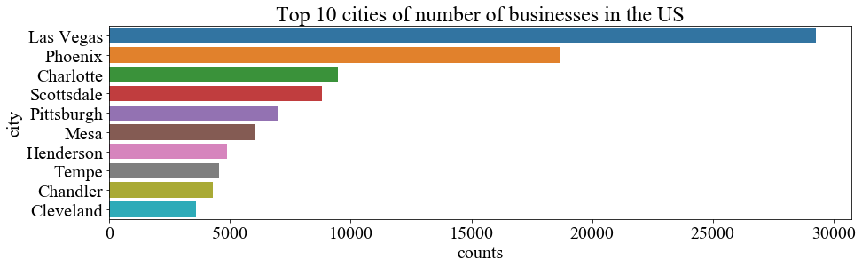

As for cities, we see Las Vegas has the most number of businesses, which is almost 30000. The city with the second largest number of businesses recorded in the US is Phoenix. Other cities in the US has less than 10000 businesses recorded in the dataset. Notice that many cities concentrated in Arizona in the Southwestern part of the US. These cities contribute a lot to the total number of businesses in Arizona. Next, take a look at Canada.

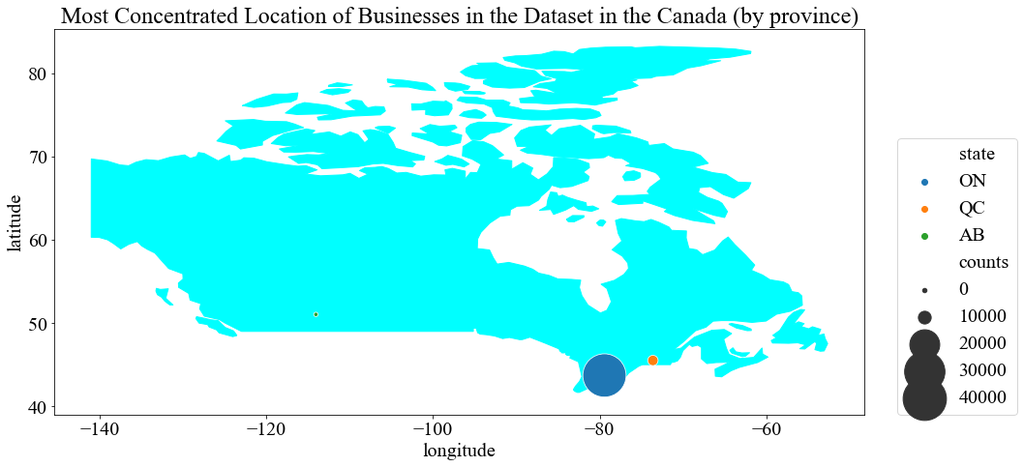

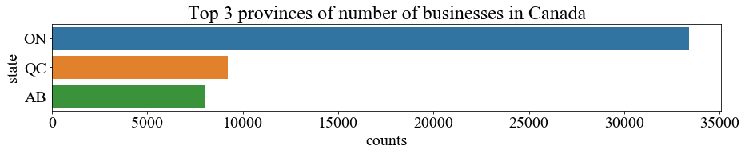

In Canada, we see most cities are concentrated in Ontario, Québec, and Alberta. And Ontario takes up most of the businesses recorded in the dataset in Canada. Futhermore, we can see the 'average' location of businesses in Ontario is approxiamtely around Toronto.

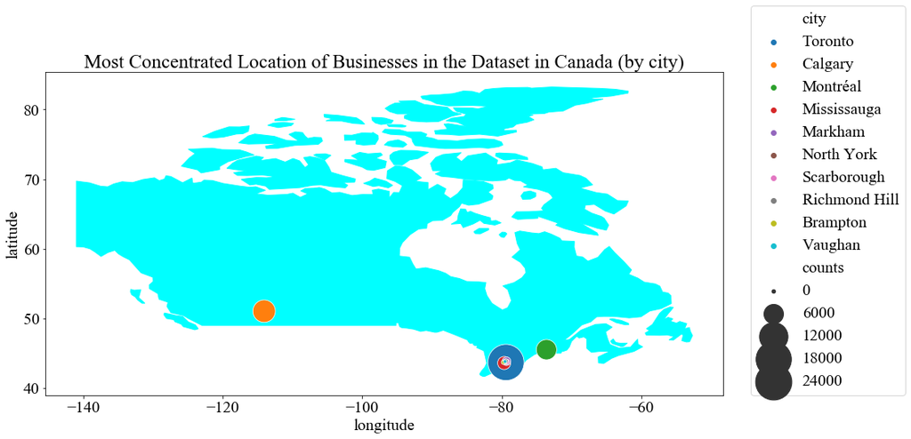

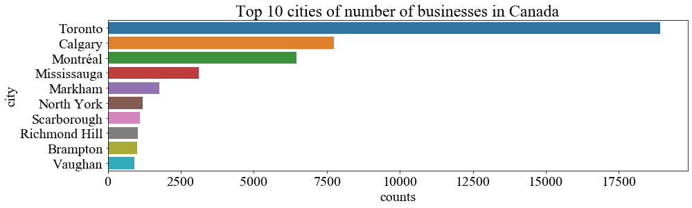

For cities in Canada, we see except Calgary and Montréal, all top 10 cities are in GTA (great Toronto Areas). It would be interesting to take a look the characteristics of businesses in GTA in the next part since we have quite a lot information about this area.

#### the Pareto principle

Also, another interesting aspect to look at is **the Pareto principle**, that is 80% of the effects come from 20% of the causes. From the map, we see a large number businesses are concentrated in some specific regions. I will now investigate, does a few ctities contribute most number of businesses in this dataset.

[figure not shown]

Using plot of cumulative distribution function, we see 20% cities with the largest number of bussinesses contains more than 98% of bussinesses in the dataset. This implies our observations from the map.

### Category

#### The most frequent business categories.

The category of business is another important feature to investigate. A business may have several categories. (For example, a business may be recorded as both restaurant type and food type). We want to investigate the category to see what is the most common catrgory in this dataframe. First, let's look at how may combination of categories we have in the data set. The procedure I will use is as the following:

1. Rearrange the category, count the frequency of each cateogory.
2. See if there is any big category, discuss the popularity of its subcategory. The most intuitive way for us to view the allocation is through map. Using longititude and latitude provided in the dataset, we can plot locations of businesses in the dataset.

```
There are 93382 combination of categories in this dataset.
```

It is a huge number, so instead of counting the number of combinations of categories, we will count the apperance of each category in the dataset. (That is, if a business is of both food category and restaurant category, I will count both of them).

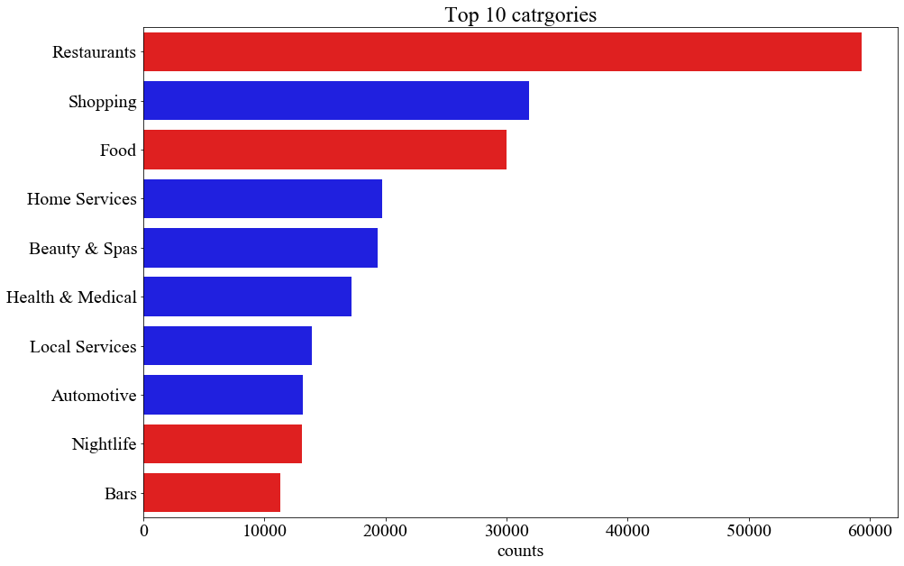

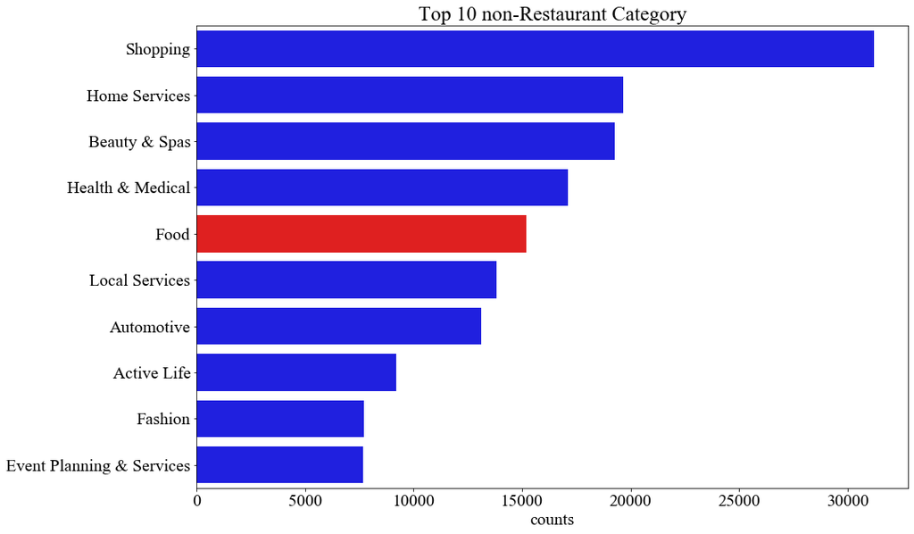

Among all non-restaurants businesses, we see shopping catogory has the highest frequency. Home serivices, Beauty & Spas and Health & Medical also have the frequency higher than 15000, indicates that more than 1 percentage of bussinesses in this data set are related to these 3 categories. Notice that there are more than about 15000 businesses recorded as food but not restaurant in the dataset. And more interestigly, there are more than 40000 businesses are recored as restaurant but not food in their catrgory attribute. Let's take a look those restaurants that do not provide food, and food businesses that are not restarants.

Although these food businesses are not recorded as restaurants, the in the 'attributes' columnm, we find many of these businesses are all related to the word 'restaurant'. For instance, a business named "Japanese Specialties" (with business id IjGU7ZopsgeomsDQf20UXQ) is not a resaurant in its category column, but has attribute recorded as "RestaurantsPriceRange2': '2'..." which is a contradiction. There is a limitation in the dataset, some are recorded restaurant but does have type restaurant.

|  | name | categories | attributes |
| --- | --- | --- | --- |
| 33 | So Cool Frozen Yogurt | Juice Bars & Smoothies, Food, Ice Cream & Frozen Yogurt | {'BusinessAcceptsCreditCards': 'True', 'RestaurantsPriceRange2': '2', 'RestaurantsTakeOut': 'True', 'BikeParking': 'False', 'WiFi': ''free'', 'Caters': 'False', 'BusinessParking': '{'garage': False, '… |

Similarly, it is also unreasonable to have restaurants not recorded as food category. This is a **limitation** in this dataset. The definition of each category is not clear and may overlap with each other (food vs. restaurant). The category attribute can be improved to a hierarchical organization to help users to read and benefit further data analysis.

By using hierarchical organization, a category cannot be paralleled with the its subcategory. This makes more sense for users. For data analysis, when we count of businesses in each subcategory, we can just select all subcategory on that level. For example, comparing number of Chinese restaurant and Canadian(New) restaurant makes more sense than comparing grocery with Chinese restaurant.

[figure not shown]

From the bar plot, we see the top 10 categories of restaurant types are evenly distributed. There is not a huge difference between two catrgories in terms of number of restaurants. Among all restaurants, nightlife and bar restaurants have the most number of businesses. Notice that fast food including pizza and burger is another category of restaurants that has a huge number.

### Convenience

#### What types of establishments tend to have higher bike parking.

1. Rearrange the category, calculate the proportion of bike available businesses under this category.
2. Rearrange the attribute, calculate the proportion of bike available businesses under this category.

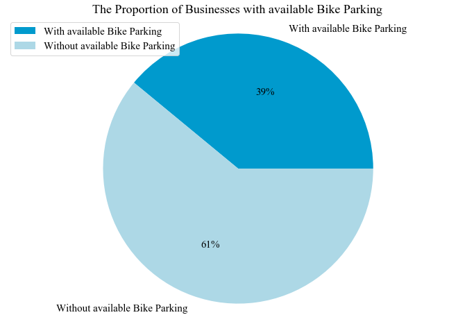

From the piechart, we see about 40% of businesses clearly indicate they provide bike parking in their establishments. As we discusses above, this data may be **inaccurate and ambiguous**. Since some establiments may not provide bike parking themselves, but there maybe public facilities with available bike parking.

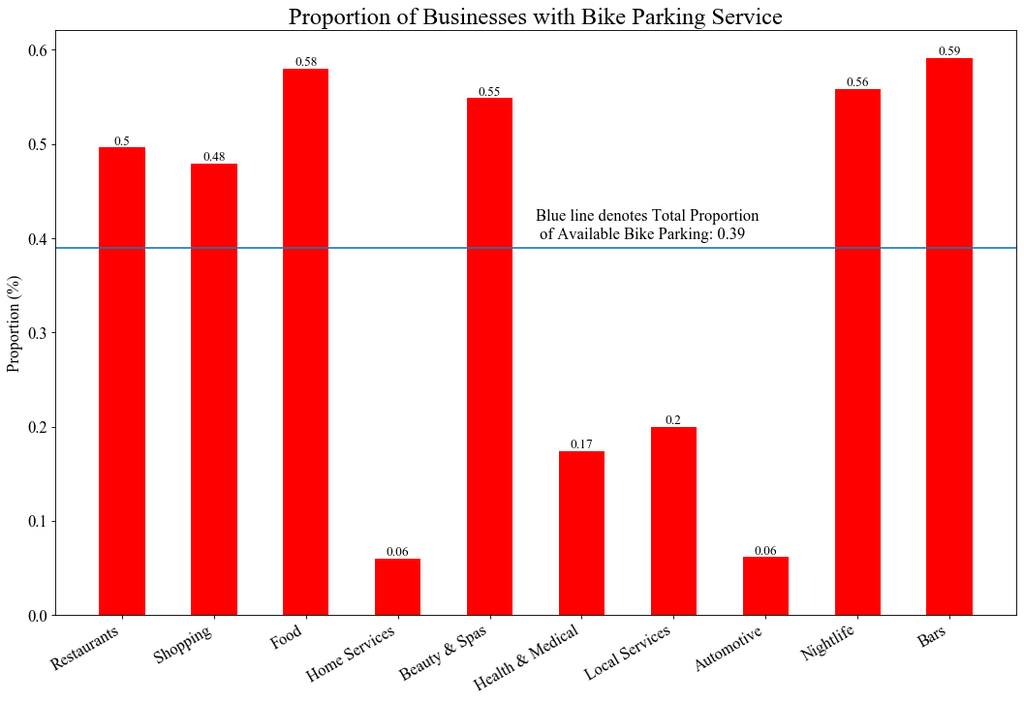

From the bar plot above, we clearly see **restaurant** and its subcategories nightlife, bar generally have a higher proportion of available bike parking service than the average proportion for all bussiness. On the other hand, **home services and automative** categories only have about 6% of its businesses provide bike parking service. This is reasonable, customers will probably go to automotive by bike.

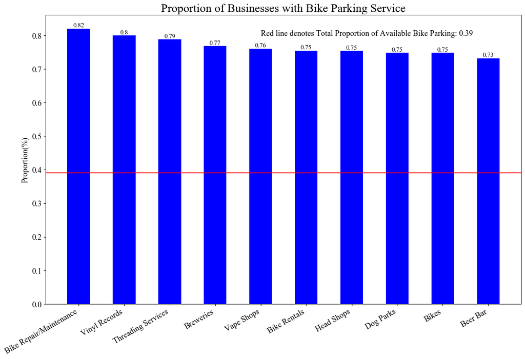

For all all categories (with number of businesses more than 50 percentile), I sort them by bike parking availability proportion and then find top 10 categories with the highest proportion. Not surprisingly, Bike Repair/Maintenance category has the highest proportion. And other bike related categories such as bike rentals and bikes also have high proporation more than 70%. While, it is interesting to see Beer Bar has a high of proportion of bike parking availability. From my point of view, this is because it is illegal to drive a car when driking too much alcohol.

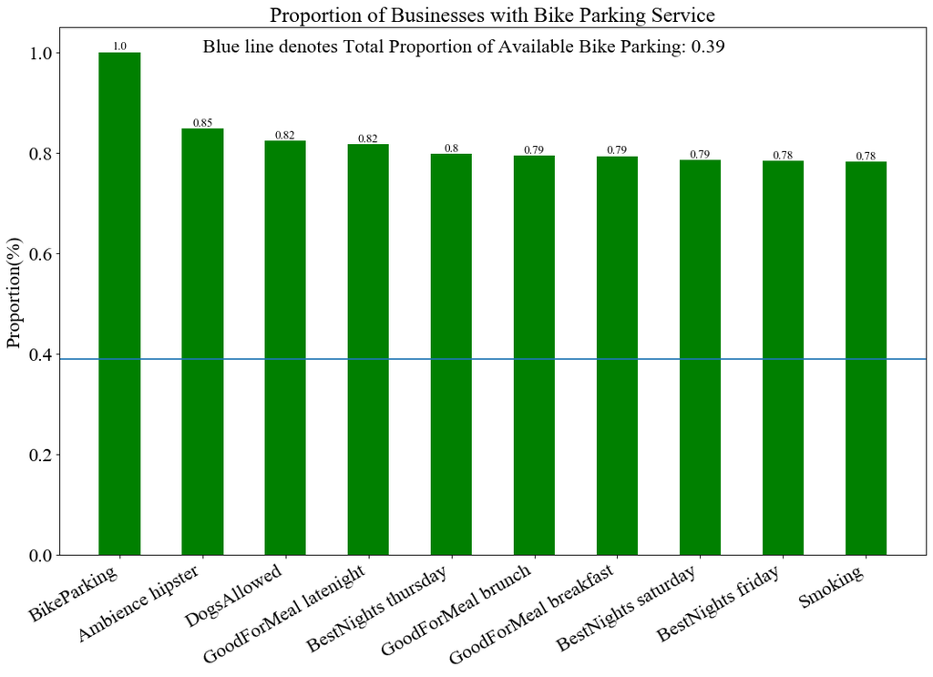

As we discussed above, bike parking availability is an indicator of the convenience of a establishment. So the last question I want to invesigate about the bike parking availability is **Does proportion of bike parking Availability relate to star evualtion for a businesses?** My approach for this question is to group the businesses in terms of their star eveluation and find the proportion of establishments with available bike parking facility for each star. Then use line plot to visualize the the relationship using line plot.

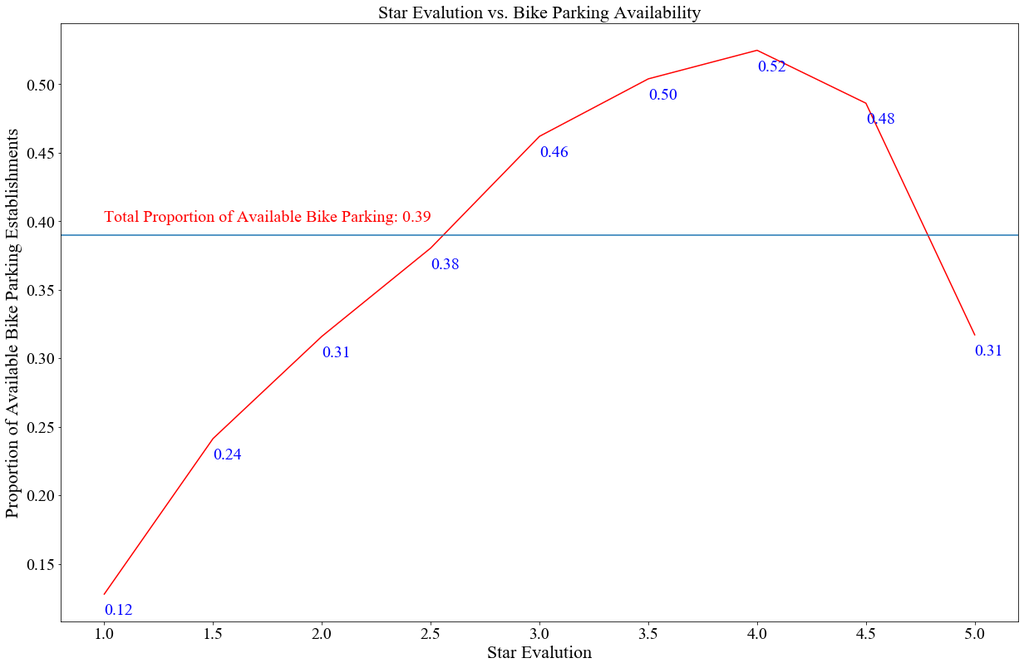

The line plot does tell us there is a positive relationship between star evaluation and availability of bike parking for an establishment. For establishments with a higher star evalution, the proportion of available bike parking facility of establishments (with that evaluation) increases as well (Notice that I am not concluding a causing relationship, but an **association**). However, when star evaluation is greater than 4.0, the proportion of available bike parking establishments decrease. This indicates that for a business to be **successful** (evaluation greater than 4), the convenience of the business matters, but for a business to be **outstanding** (evaluation reaches 5), there maybe other more important aspects to look at.

### Reviews and Rating

#### Initial Guess

According to an article that was published recently, having more yelp reviews result in a higher rating, and this helps increase the sales indirectly. Using the dataset we have, we can investigate this relationship deeper than random guessing. Let's first take a look at two attributes.

#### Procedure

The standard deviation(110.1) for review counts is of greater magnitude than its mea(33.5)n can indicate that there may be several outliers with very high review counts (also because of mean is higher than median value of this attribute). Therefore, the correlation of these two variables may be deeply influenced by those outliers. However, the restaurants with extremely high review counts are also important to our result, so we can not just simply drop them.

So the procedure I chose for this question is through arrange 'review_count' attribute into 5 categorical value:

0 to 20(th)percentile, 20 to 40(th)percentile, 40 to 60(th)percentile, 60 to 80(th)percentile, 80 to 100(th)percentile.

And combine 'stars' attribute into 5 categorical variable:

1.0 to 1.5 star, 2.0 to 2.5 star, 3.0 to 3.5 star, 4.0 to 4.5 star, 5.0 star. And visualize the relationship using stacked bar plot.

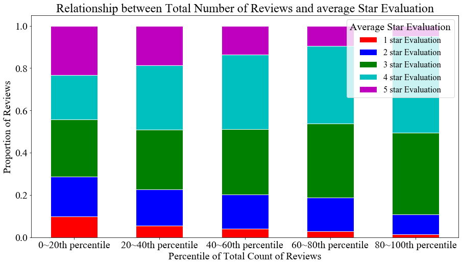

From the stacked bar plot, we first take a look the area of red rectangles in different bars. The area of red rectangle has a decreasing trend, which indicates that along with the increase of number of reviews, the proportion of 1 star evaluation decreses. Surprisingly, there is a similar trend for purple rectangle. Therefore, we may conclude that for businesses with more number of reviews, its proportion of extreme high or low evaluation decrease. This is reasonable, think about it using analogy of 'the Law of Large Number', more reviews a business has, the mean of its evalution stars should get closer the expectation (in this case, the expectation is around 3-4 stars).

The area of cyan-blue rectangle increases along with the number of reviews. Which implies that there is a postive association between number of 4 star evaluation and the total review counts of a business. This does not help statement in the article directly, but does depicts the relationship between star evaluation and number of reviews.

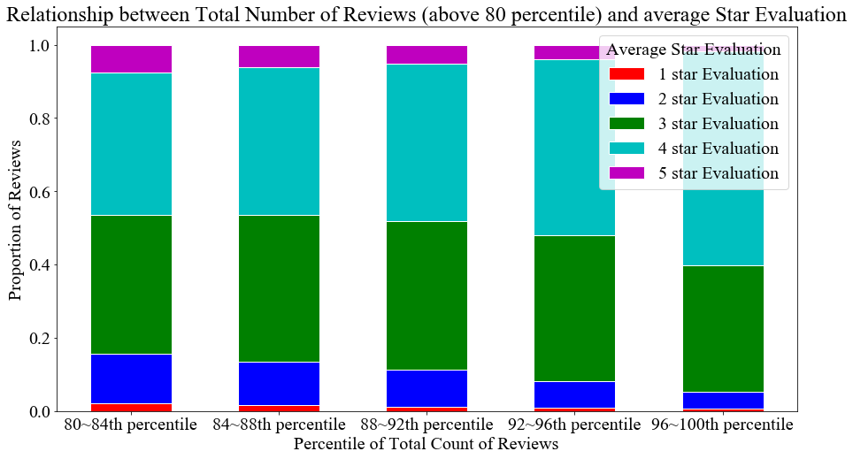

Since, we know there are businesses with extremely high number of reviews, the relationship may look different for these businesses. So I use a seperate stacked bar plot to visualize the relationship between review counts and star evaluation when review counts is extremely high (higher than 80th percentile). The approach is similar as before. And trend is similar as well, we can see from 96th to 100th percentile of review counts, there are more than half of evaluations are 4 stars. Therefore, for extreme cases, the relationship is similar as normal cases.

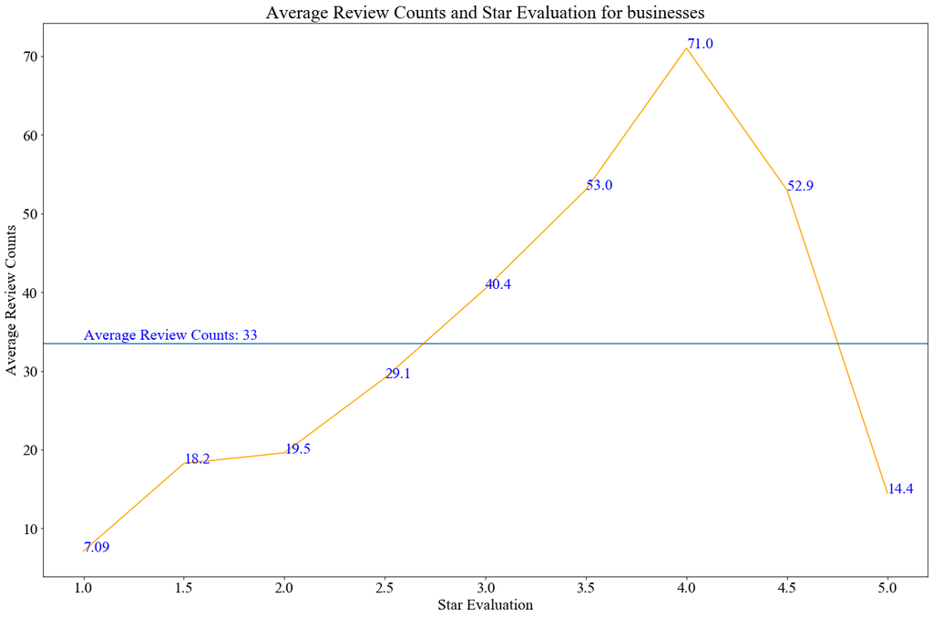

Lastly, we plot a lineplot to visualize the relationship between star evalution and review counts for businesses. Comparing to the stacked bar plot, we reverse x-axis and y-axis in this case. We can clearly see that for all businesses with 4 stars evalution, they have the most number of average review counts, about 71.0. This means more reviews a business has, the more likely for it to be evaluated at 4 star.

## Characteristics of GTA Businesses

From the previous part, we see there are many businesses located in GTA. It is always useful to go from overall to a partition of the dataset. Since we lived in GTA, it became more interetsing to take a look at the neighborhood from a new perspetive. So, in this part, I will focus on businesses in GTA, and make connection between them to the all the businesses dataset. Firstly, I want to filter bussiness that are located in Ontario to get a dataframe only contains GTA businesses.

### GTA data

From the map, we see most of the data are located in the GTA. While, there is one bussiness located at the right side of Ontario. I will drop it to form a dataframe only contains bussinesses in the GTA.

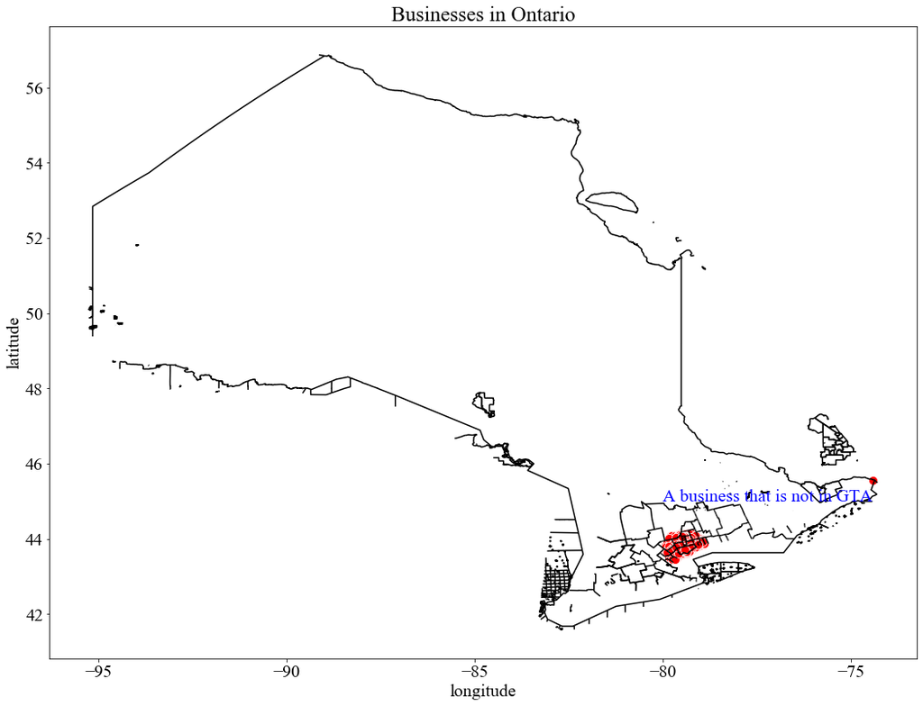

### Category

#### The Whole vs. The Part

In the last part, we investigated the popularity of categories in the whole data frame. However, we know Toronto is a special city with its unique characteristics in all ways. It is interesting to do a "the whole and the part" comparision for this topic. If the popular categories are different in Toronto, we may also look deeper into what is behind this difference.

#### Procedure

The procedure I will follow for this question is roughly:

1. Find top 10 frequent categories in GTA, compare it with the result of the whole dataset.
2. Find top 10 restaurant categories in GTA, compare it with the result of the whole dataset.
3. Apply further investigation on the reason behind difference/similarity.

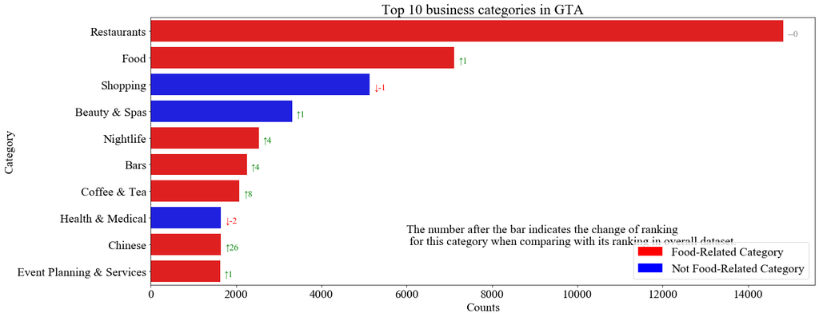

From the plot of top categories, we see restaurant still keeps its leading position. Food category and shopping reverse their ranking, which indicates people in GTA tend to be more interested in food businesses. Other businesses related to food also had more or less increasing trends including nightlife, bars and coffee & tea and Chinese. There is also no dramatic increase or decrease for other categories. For coffee&tea culture, we can relate it to two most common coffee brands in Toronto: Tim Hortons and Starbucks, and I will do further exploration in the next part.

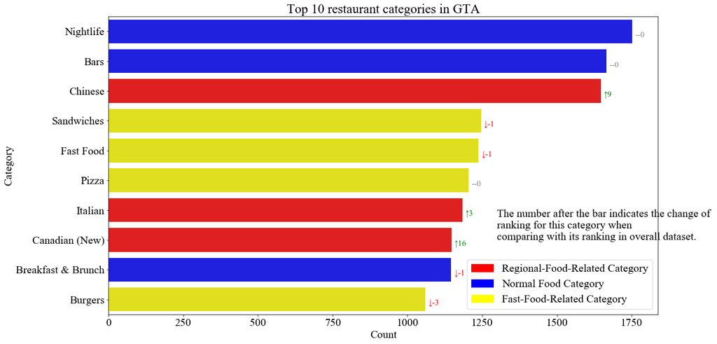

[figure not shown]

This pie chart clearly shows that Chinese ethnicity group has a high proportion of population in Toronto. Simiarly, 7% of Toronto population also has Italian background, this can explain why Chinese food and Italian food are so popular in GTA.

### Popularity

#### Top franchises in the city

In addition to category, franchises are important for bussinss's development. Unlike normal businesses, franchises have a larger scale of branch businesses, they are more adaptable for urbanmerket. In this part, I will explore more about franchises in GTA. Notice that the way I define franchisise business in this part is: if two businesses have the exact same name in the business dataframe, I will treat them as franchises.

#### Procedure

1. Modify incorrect names of businesses into correct ones. For example, "Tim Hortons" and "Tim Horton's" are both recorded in the dataset, one of them should be modified in order to ensure the accuracy of the result.
2. Rank franchises based on
   1. Total Number of Branch Businesses
   2. Average Review Counts
   3. Average Star Evaluation
3. Check if there is any relationship between three variables above.

First, I will modify the names of businesses using fuzzwuzzy package.

```
For instance, we may have similar names as below, and we need to standardize them
```

```
[("Tim Horton's", 'Tim Hortons'),
 ("Tim Horton's", "Tim Horton's"),
 ("Tim Horton's", 'Tim Horton Donuts'),
 ("Tim Horton's", 'Tim Horton'),
 ("Tim Horton's", 'Tim hortons')]
```

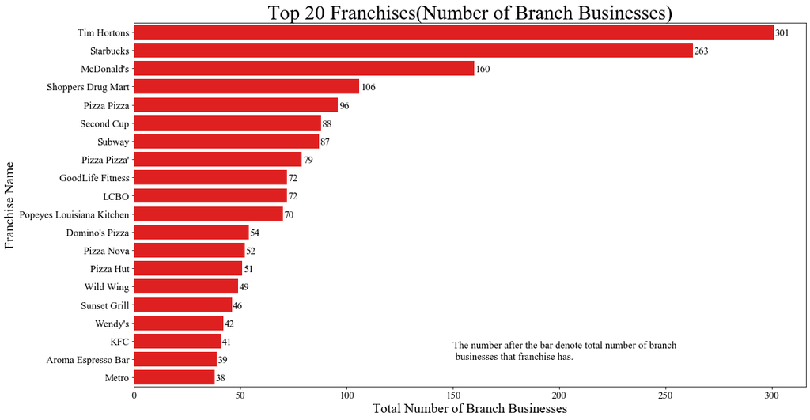

From the bar plot, we see Tim Hortons and Starbucks have the highest number of branch businesses in GTA. Only thees have more than 200 branch businesses in GTA. And we could also see, most of franchises in the ranking are food related. For non-food related franchises, Shoppers Drug Market is the highest among tgem, it has 106 branch businesses in total.

Now, in order to compare other attrbutes (review_counts, stars) franchines in order to to have a better understanding of this dataset.

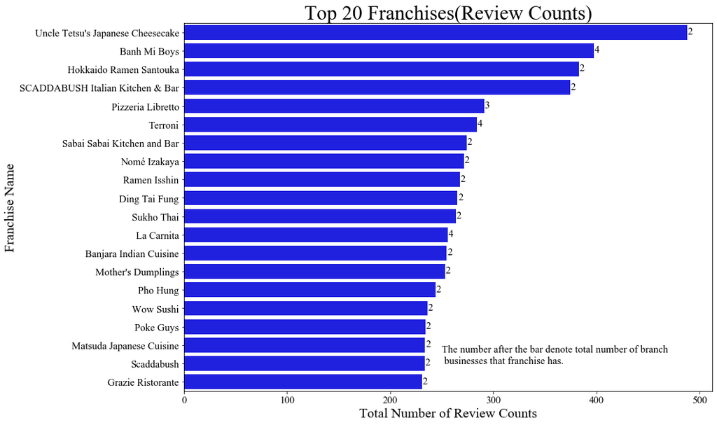

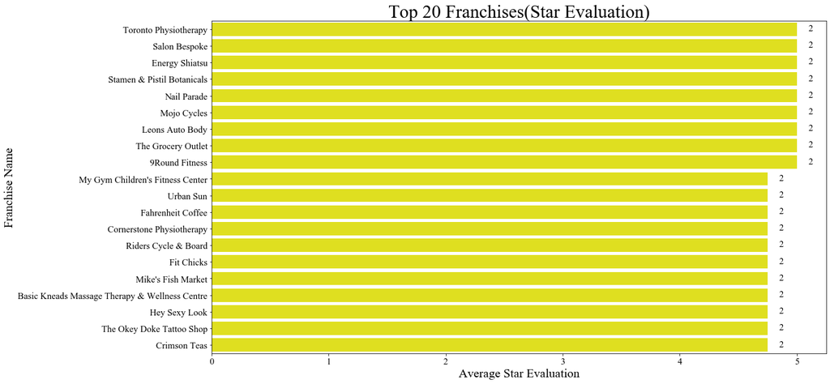

Lastly, when we compare franchises using their average star evalution. Surprisingly, we find all of franchises with a high average star evalution has only 2 branch businesses. Now, we may think about is there a negative correlation between these variables, and I will use heatmap to visualize if there is any correlation.

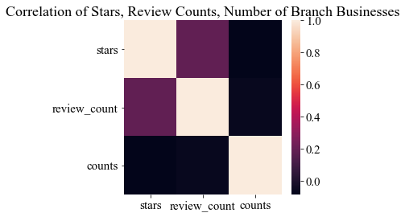